# bbricks-getting-started

### Hidden Markov Model (HMM)

A Hidden Markov Model (HMM) has following graphical model structure:

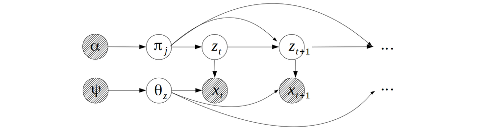

The CPDs are:
$$\begin{align}
\pi_j & \sim Dirichlet(\alpha), j=0:J\\
z_{t+1}|z_t,\pi_j & \sim Categorical(\pi_{z_t}) \\
x_t|\theta_z,z_t & \sim F(\theta_{z_t}) \\
\theta_z | \psi & \sim H(\psi)
\end{align}$$
Where $\pi_0$ is the initial distribution, $\pi_j,j=1:J$ are the transition distributions of each state. $F(.)$ is the observation distribution, $H(.)$ is the prior distribution of the $\theta$s.

In **bbricks** the Categorical-Dirichlet structures are initialized with `"CatDirichlet"` objects. The choice of the `"BasicBayesian"` structure, i.e. the choice of $F(.)$ and $H(.)$, is flexible, for example if we set $F=Gaussian$ and $H=NIW$, then the structure $\psi \rightarrow \theta \rightarrow x$ can be initialized with an `"GaussianNIW"` object.

For demo purpose here shows an example using the **single-move sampling** discussed in Robert et al (1993), Frühwirth-Schnatter (2006). In the example the observations are generated by 3 two-dimensional Gaussian distribution. The R code is:

```r
## Learn HMM posteriors using single-move sampling

library(bbricks)

## load some hidden markov data
## see ?hmmData for details
data(hmmData)
x <- hmmData$x
Nsegs <- hmmData$Nsegs                  #number of segments
breaks <- hmmData$breaks                #break index of the segments
## Step1: Initialization------------------------------------------
## create Categorical-Dirichlet object for pi0 and transition matrix
K <- 3L
allk <- 1L:K
transitionObj <- replicate(K,CatDirichlet(gamma = list(alpha=1,uniqueLabels=allk)))
piObj <- CatDirichlet(gamma = list(alpha=1,uniqueLabels=allk))
## create Gaussian-NIW object for observations
obsObj <- replicate(K,GaussianNIW(gamma=list(m=c(0,0),k=0.001,v=3,S=diag(2))))
## place holder for the sampled hidden states
z <- integer(nrow(x))
## observation sufficient statistics
ssx <- sufficientStatistics(obj = obsObj[[1]],x=x,foreach = TRUE)
## initialize states with random assignment
z <- sample(allk,length(z),replace = TRUE)
for(i in 1L:Nsegs){
    segStart <- breaks[i]+1L
    segEnd <- breaks[i+1]
    for(j in segStart:segEnd){
        if(j==segStart) posterior(piObj,ss = z[j])
        else posterior(transitionObj[[z[j-1L]]],ss = z[j])
        posterior(obsObj[[z[j]]],ss = ssx[[j]])
    }
}
## Step2: main Gibbs loop---------------------------------------------
maxit <- 20
it <- 1
pb <- txtProgressBar(min = 0,max = maxit,style = 3)
while(it<=maxit){
    ## for all segments
    for(i in 1L:Nsegs){
        segStart <- breaks[i]+1L
        segEnd <- breaks[i+1]
        for(j in segStart:segEnd){
            ## discard previous z
            if(j==segStart){
                posteriorDiscard(piObj,ss = z[j])
            }else if(j==segEnd){
                posteriorDiscard(transitionObj[[z[j-1L]]],ss = z[j])
            }else{
                posteriorDiscard(transitionObj[[z[j-1L]]],ss = z[j])
                posteriorDiscard(transitionObj[[z[j]]],ss = z[j+1L])
            }
            posteriorDiscard(obsObj[[z[j]]],ss = ssx[[j]])
            ## sample new z
            if(j==segStart)
                pz <- dPosteriorPredictive(obj = piObj,x=allk,LOG = TRUE)
            else
                pz <- dPosteriorPredictive(obj = transitionObj[[z[j-1L]]],x=allk,LOG = TRUE)
            if(j!=segEnd)
                for(k in allk) pz[k] <- pz[k]+dPosteriorPredictive(obj = obsObj[[k]],x=x[j,,drop=FALSE],LOG = TRUE)+dPosteriorPredictive(obj = transitionObj[[k]],x=z[j+1L],LOG = TRUE)
            else
                for(k in allk) pz[k] <- pz[k]+dPosteriorPredictive(obj = obsObj[[k]],x=x[j,,drop=FALSE],LOG = TRUE)
            pz <- exp(pz-logsumexp(pz))
            currentK <- sample.int(K,size=1,prob = pz)
            z[j] <- currentK
            ## update prior with newly sampled z
            if(j==segStart){
                posterior(piObj,ss = currentK)
            }else if(j==segEnd){
                posterior(transitionObj[[z[j-1L]]],ss = currentK)
            }else{
                posterior(transitionObj[[z[j-1L]]],ss = currentK)
                posterior(transitionObj[[currentK]],ss = z[j+1])
            }
            posterior(obsObj[[currentK]],ss = ssx[[j]])
        }
    }
    it <- it+1
    setTxtProgressBar(pb,it)
}
## print the MAP estimates of the transition matrix
for(k in allk) print(round(MAP(transitionObj[[k]]),2))
## print the MAP estimates of the observation distributions
for(k in allk) print(MAP(obsObj[[k]]))
## MAP estimates of the initial state distribution pi0
MAP(piObj)
```

### Infinite States Hidden Markov Model (HDP-HMM)

An infinite state hidden Markov model can be represented by a hierarchical Dirichlet process according to Teh (2005), the graphical model for HDP-HMM is:

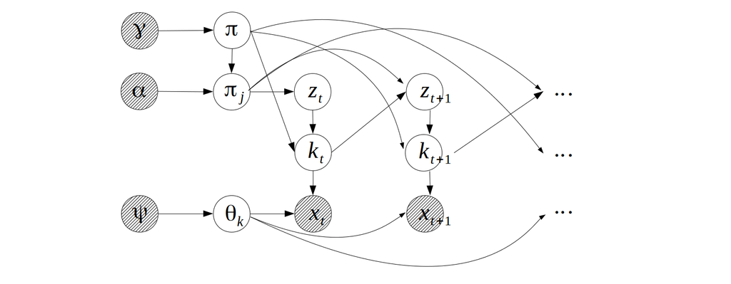

The CPDs are:
$$\begin{align}
\pi|\gamma & \sim DP(\gamma) \\
\pi_j |\alpha,\pi & \sim DP(\alpha,\pi) \\
z_{t+1} | \pi_j,z_t,k_t & \sim Categorical(\pi_j) \text{, if }k_t=j \\
k_{t}| z_t,\pi & \sim Categorical(\pi) \text{, if }z_t\text{ is a sample from } \pi\\
\theta_k | \psi & \sim H(\psi) \\
x|\theta_k,k_t & \sim F(\theta_{k_t})
\end{align}$$
Like the one described in Hierarchical Mixture Models, **bbricks** provides an object of type `"HDP"` to encode such structures.

For demo purpose I’ll use the simple **single-move sampling** method discussed in Robert et al (1993), Frühwirth-Schnatter (2006) to learn the posterior distributions of the model parameters. See Van Gael et al (2008) for a more efficient implementation.

The R code is:

```r
## Learn HDP-HMM posteriors using single-move sampling

library(bbricks)

source("Programs/Codes/Bayesian Nonparametrics/Dirichlet_Process.r")
## load some hidden markov data
## see ?hmmData for details
data(hmmData)
x <- hmmData$x
Nsegs <- hmmData$Nsegs
breaks <- hmmData$breaks
## Step1: Initialization------------------------------------------
transitionObj <- HDP(gamma = list(gamma=1,alpha=1,j=1,H0aF="GaussianNIW",parH0=list(m=c(0,0),k=0.001,v=3,S=diag(2))))
## place holder for the sampled hidden states
zk <- matrix(0L,ncol = 2,nrow = nrow(x))
## observation sufficient statistics
ssx <- sufficientStatistics(obj = GaussianNIW(),x=x,foreach = TRUE)
## sample k from p(k|gamma,x)
samplePi <- function(x,zkAfter){
    ## allK <- which(transitionObj$Z$Z1$gamma$nk>0)
    allK <- which(transitionObj$Z$Z1$gamma$nk>0) #all possible k
    if(length(allK)==0) return(transitionObj$Z$Z1$gamma$newLabel)
    ## p(k|pi) p(x|k) p(k_{2}|k)
    logp <- dPosteriorPredictive(transitionObj$Z$Z1,x=allK,LOG = TRUE) +
        vapply(allK,function(k){
            dPosteriorPredictive(transitionObj$X[[k]],x=x,LOG = TRUE)+
            dPosteriorPredictive(obj = transitionObj,z=zkAfter[1],k=zkAfter[2],j=k,LOG = FALSE)
        },FUN.VALUE = numeric(1))

    logp <- exp(logp-max(logp))
    allK[sample.int(length(allK),size = 1,prob = logp)]
}
## sample z and k from p(z,k|gamma,alpha,x)
sampleZK <- function(kBefore,zkAfter,x){
    ## p(z,k | k_{t-1}) p(x|k)
    probs <- dAllIndicators(obj = transitionObj,j=kBefore,x=x)
    ##
    allK <- unique(probs$k)

    ## p(k_{t+1} | k)
    p <- vapply(allK,function(k){
        if(k==transitionObj$Z$Z1$gamma$newLabel)
            dPosteriorPredictive(obj = transitionObj$Z$Z1,x=zkAfter[2],LOG = FALSE)
        else
            dPosteriorPredictive(obj = transitionObj,z=zkAfter[1],k=zkAfter[2],j=k,LOG = FALSE)
    },FUN.VALUE = numeric(1))
    idx <- sample.int(nrow(probs),size = 1,prob = p[match(probs$k,allK)]*probs$p)
    c(z=probs$z[idx],k=probs$k[idx])
}
## initialize states with forward assignment
for(i in 1L:Nsegs){
    segStart <- breaks[i]+1L
    segEnd <- breaks[i+1]
    for(j in segStart:segEnd){
        if(j==segStart){
            k <- rPosteriorPredictive(obj = transitionObj$Z$Z1,n=1)
            ## update initial and observation
            posterior(obj = transitionObj,ss=ssx[[j]],ss1=k,ss2=1L,j=k)
            zk[j,2] <- k
        }else{
            ## sample from the j(or k) th DP
            zk1 <- rPosteriorPredictive(obj = transitionObj,n=1,j=zk[j-1,2],x=x[j,,drop=FALSE])
            ## update transition and observation
            posterior(obj = transitionObj,ss = ssx[[j]],ss1=zk1[2],ss2=zk1[1],j=zk[j-1,2])
            ## write to book
            zk[j,] <- zk1
        }
    }
}
## Step2: main Gibbs loop---------------------------------------------
maxit <- 20
it <- 1
pb <- txtProgressBar(min = 0,max = maxit,style = 3)
while(it<=maxit){
    ## for all segments
    for(i in 1L:Nsegs){
        segStart <- breaks[i]+1L
        segEnd <- breaks[i+1]
        for(j in segStart:segEnd){
            ## discard previous z
            if(j==segStart){
                ## discard 1 obs 1 initial and 1 transition
                posteriorDiscard(obj = transitionObj,ss=ssx[[j]],ss1=zk[j,2],ss2=1L,j=zk[j,2])
                posteriorDiscard(obj = transitionObj,ss=NULL, ss1=zk[j+1,2],ss2=zk[j+1,1],j=zk[j,2])
                ## sample new initial k
                k <- samplePi(x=x[j,,drop=FALSE],zkAfter = zk[j+1,,drop=FALSE])
                ## update prior with newly sampled k
                posterior(obj = transitionObj,ss=ssx[[j]],ss1=k,ss2=1L,j=k)
                posterior(obj = transitionObj,ss=NULL, ss1=zk[j+1,2],ss2=zk[j+1,1],j=k)
                ## write to book
                zk[j,2] <- k
            }else if(j==segEnd){
                ## discard 1 obs and 1 transition
                posteriorDiscard(obj = transitionObj,ss=ssx[[j]],ss1=zk[j,2],ss2=zk[j,1],j=zk[j-1,2])
                ## sample new z k
                zk1 <- rPosteriorPredictive(obj = transitionObj,n=1,x=x[j,,drop=FALSE],j=zk[j-1,2])
                ## update prior with newly sampled z
                posterior(obj = transitionObj,ss=ssx[[j]],ss1=zk1[2],ss2=zk1[1],j=zk[j-1,2])
                ## write to book
                zk[j,] <- zk1
            }else{
                ## discard 2 transitions and 1 obs
                posteriorDiscard(obj = transitionObj,ss=ssx[[j]],ss1=zk[j,2],ss2=zk[j,1],j=zk[j-1,2])
                posteriorDiscard(obj = transitionObj,ss=NULL, ss1=zk[j+1,2],ss2=zk[j+1,1],j=zk[j,2])
                ## sample new z k
                zk1 <- sampleZK(kBefore = zk[j-1,2],zkAfter = zk[j+1,],x=x[j,,drop=FALSE])
                ## update prior with newly sampled z k
                posterior(obj = transitionObj,ss=ssx[[j]],ss1=zk1[2],ss2=zk1[1],j=zk[j-1,2])
                posterior(obj = transitionObj,ss=NULL, ss1=zk[j+1,2],ss2=zk[j+1,1],j=zk1[2])
                ## write to book
                zk[j,] <- zk1
            }
        }
    }
    it <- it+1
    setTxtProgressBar(pb,it)
}
allK <- which(transitionObj$Z$Z1$gamma$nk>0)
## print the MAP estimates of the state transitions
for(k in allK) print(vapply(split(MAP(transitionObj$Z$Z2[[k]]),f=transitionObj$Z$Z12map[[k]]),sum,numeric(1)))
## print the MAP estimates of the observation parameters
for(k in allK) print(MAP(transitionObj$X[[k]]))
## print the MAP esitmate of the initial state distribution
round(MAP(transitionObj$Z$Z1)[allK],2)
```

## References

Andrieu, Christophe, et al. “An introduction to MCMC for machine learning.” *Machine learning* 50.1-2 (2003): 5-43.

Johnson, Valen E., and James H. Albert. *Ordinal data modeling*. Springer Science & Business Media, 2006.

Hoff, Peter D. *A first course in Bayesian statistical methods*. Vol. 580. New York: Springer, 2009.

Li, Yuelin, Elizabeth Schofield, and Mithat Gönen. “A tutorial on Dirichlet process mixture modeling.” *Journal of Mathematical Psychology* 91 (2019): 128-144.

MARolA, K. V., JT KBNT, and J. M. Bibly. Multivariate analysis. AcadeInic Press, Londres, 1979.

McLachlan, Geoffrey J., and Thriyambakam Krishnan. *The EM algorithm and extensions*. Vol. 382. John Wiley & Sons, 2007.

Murphy, Kevin P. *Machine learning: a probabilistic perspective*. MIT press, 2012.

Robert, Christian P., Gilles Celeux, and Jean Diebolt. “Bayesian estimation of hidden Markov chains: A stochastic implementation.” *Statistics & Probability Letters* 16.1 (1993): 77-83.

Frühwirth-Schnatter, Sylvia. *Finite mixture and Markov switching models*. Springer Science & Business Media, 2006.

Smith, W. B., and R. R. Hocking. *Algorithm as 53: Wishart variate generator.* Journal of the Royal Statistical Society. Series C (Applied Statistics) 21.3 (1972): 341-345.

Teh, Yee Whye. “Dirichlet Process.” (2010): 280-287.

Teh, Yee W., et al. “Sharing clusters among related groups: Hierarchical Dirichlet processes.” *Advances in neural information processing systems*. 2005.

Van Gael, Jurgen, et al. “Beam sampling for the infinite hidden Markov model.” *Proceedings of the 25th international conference on Machine learning*. 2008.

Wishart, John. “The generalized product moment distribution in samples from a normal multivariate population.” Biometrika (1928): 32-52.